# Chronic Kidney Disease

## Introduction

- **Chronic kidney disease** (**CKD**) is a type of kidney disease in which there is gradual loss of kidney function over a period of months to years
- The main risk factors for developing kidney disease are diabetes, high blood pressure, heart disease, and a family history of kidney failure
- The two key markers for CKD are urine albumin and eGFR (based on measuring the stable serum creatinine levels)

## Materials and Methods

1. Cleaning and augmenting
2. Data exploration
3. Data analysis - *PCA*
4. Modelling - *Linear regression and K-nearest neighbors*

## Materials and Methods

### **The Data-set**

- The data-set was obtained from **UCI Machine Learning Depository**
- **400 observations of 25 attributes**:
  - numerical (15): albumin, blood urea,  
    serum creatinine, hemoglobin,  
    packed cell volume, and others
  - categorical (10): class, anemia,  
    diabetes melitus and others.

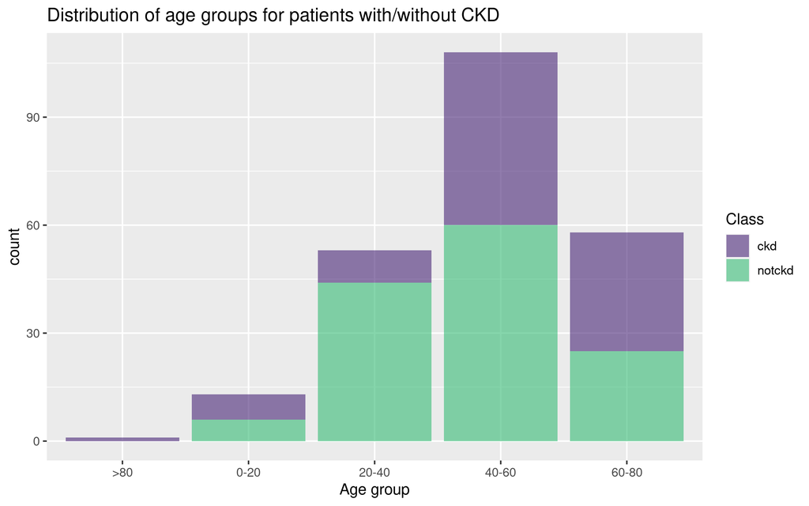

## Data loading, cleaning and augmentation

1. **Loading****:** Artificially splitting the data-set in **2 groups:** Healthy patients and patients with CKD and then joining
2. **Cleaning:**

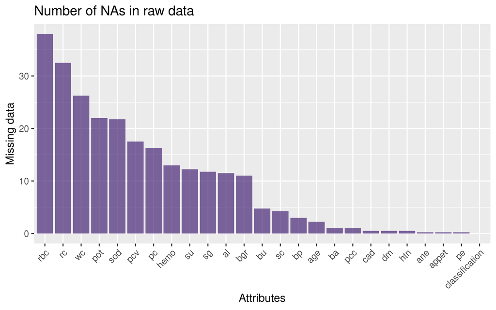

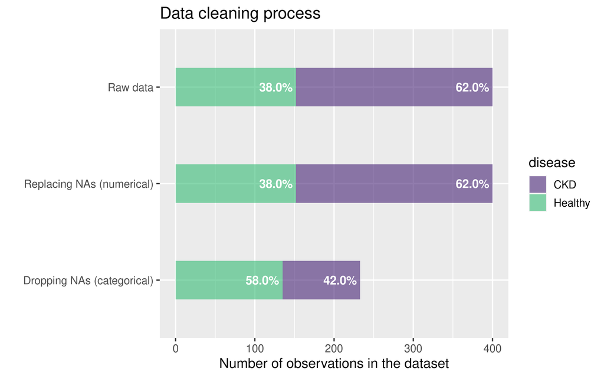

**3. Augmenting:** Creating new variables *Age_group, Disease_no, Disease_type*

## Results and Discussion

### **Data exploration**

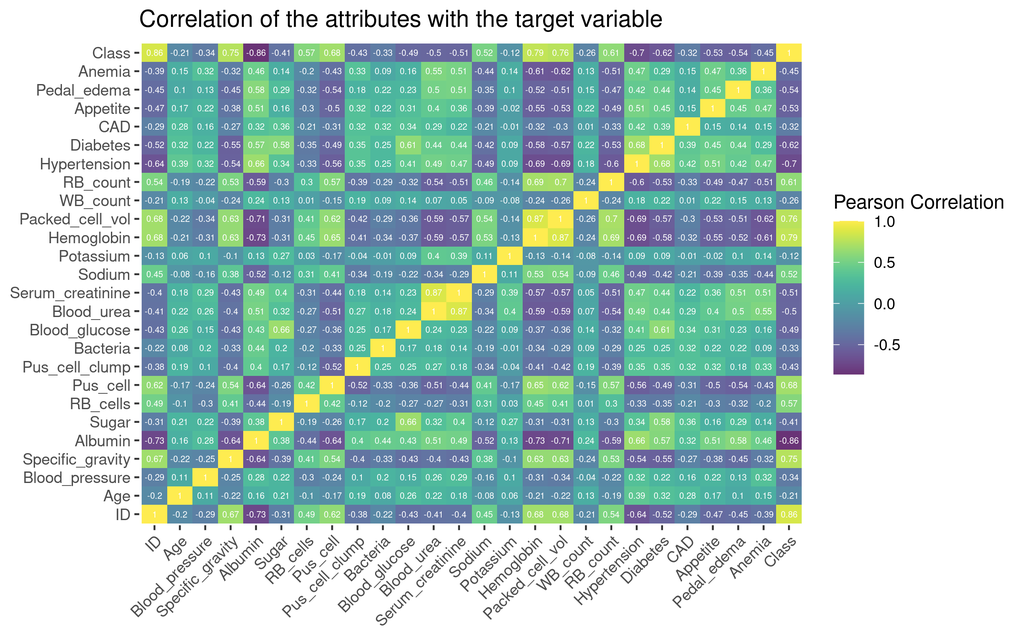

## Data Visualization

### **Hemoglobin and Packed Cell Volume relationship**

- Hemoglobin analysis results in clear separation between classes: sick and healthy patients
- Low hemoglobin (and low PCV) are related to anemia, a common CKD complication

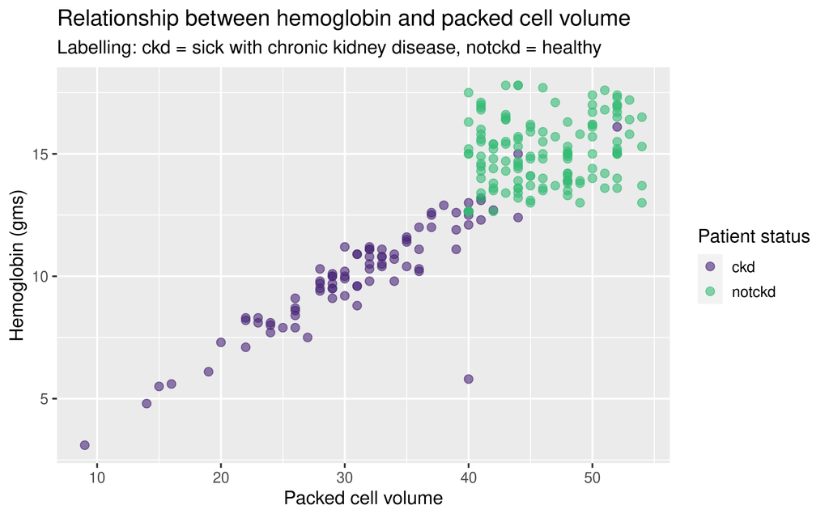

## Data Visualization

### **Hemoglobin and Serum Albumin relationship**

- Albumin = number of positive tests for albumin in the urine (discrete)
- Excess albumin in the urine (low serum albumin) is an indicator of kidney failure

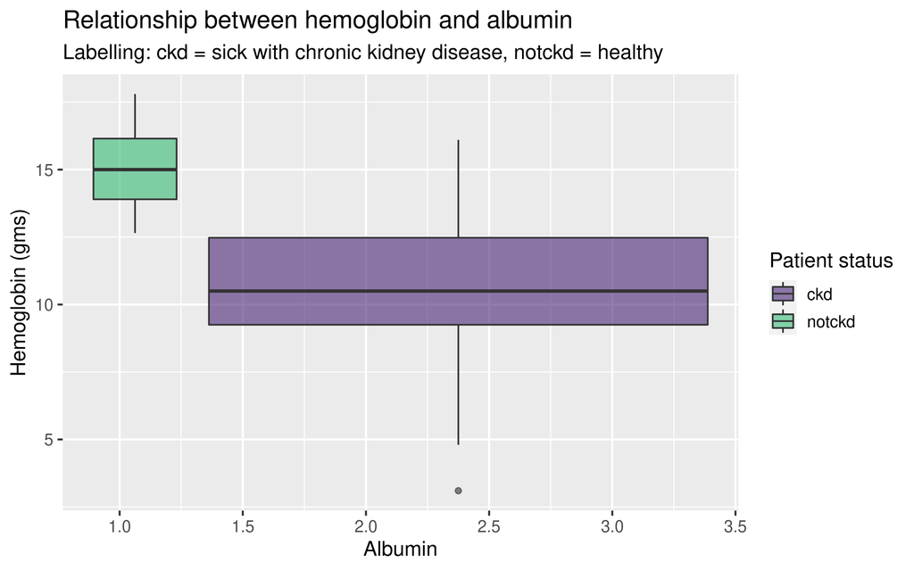

## Data Visualization

### **Serum Creatinine and Blood Urea relationship**

- Most common markers for assessing renal function: the glomerular filtration rate (rapid decline of GFR associated with CKD)

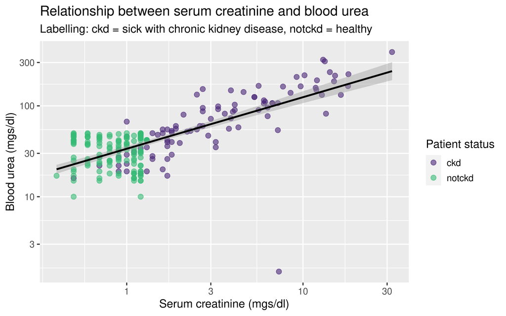

## Principal component analysis

### Variability

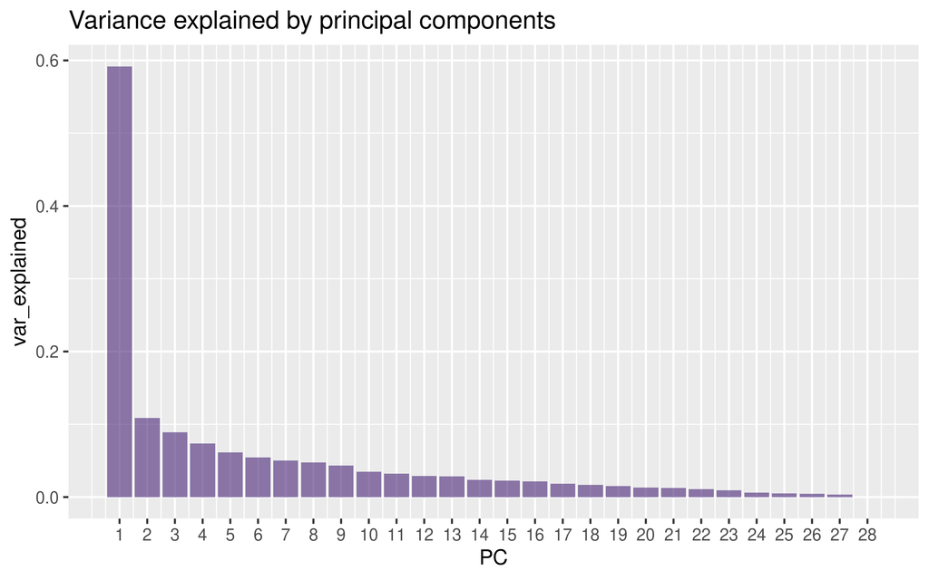

## Principal component analysis

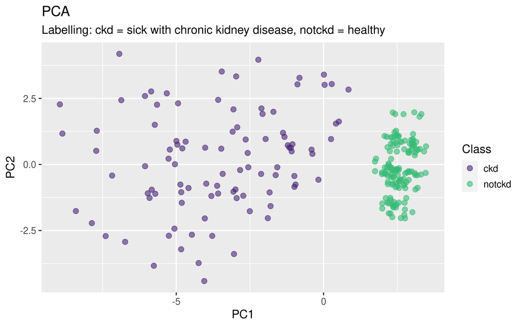

## Modelling

### Linear regression - all predictors

- 90% sensitivity at 100% specificity

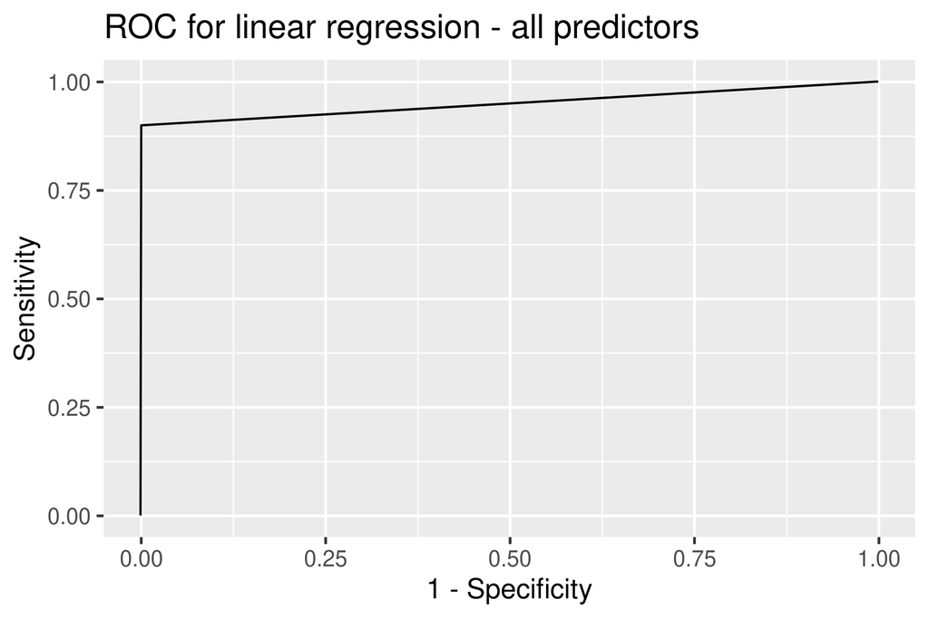

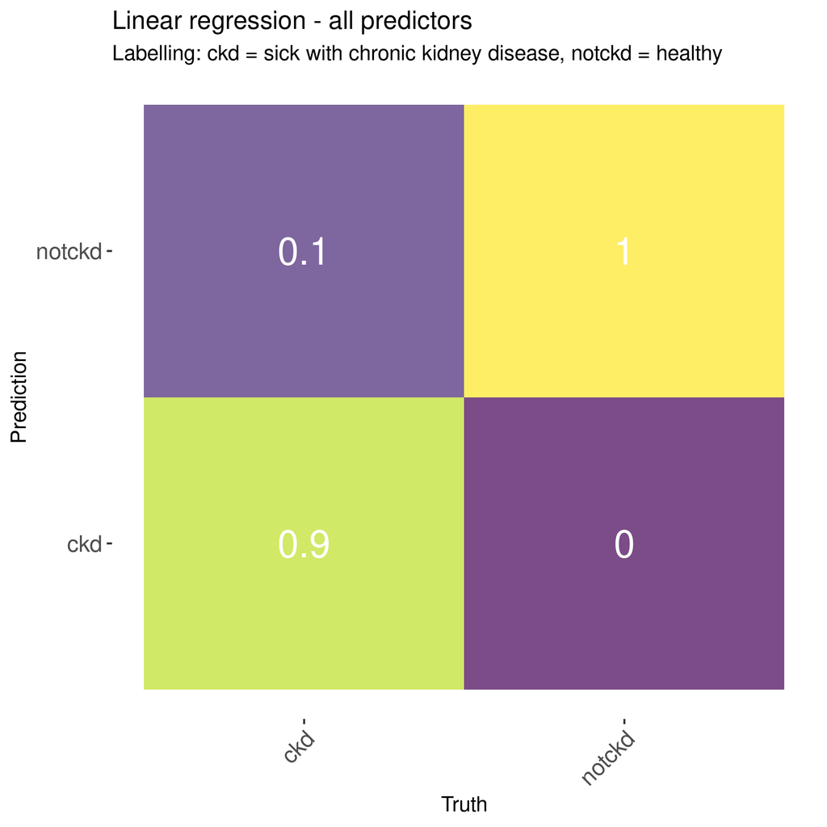

## Modelling

### Linear regression - Hemoglobin and PCV

- 100% sensitivity at 100% specificity

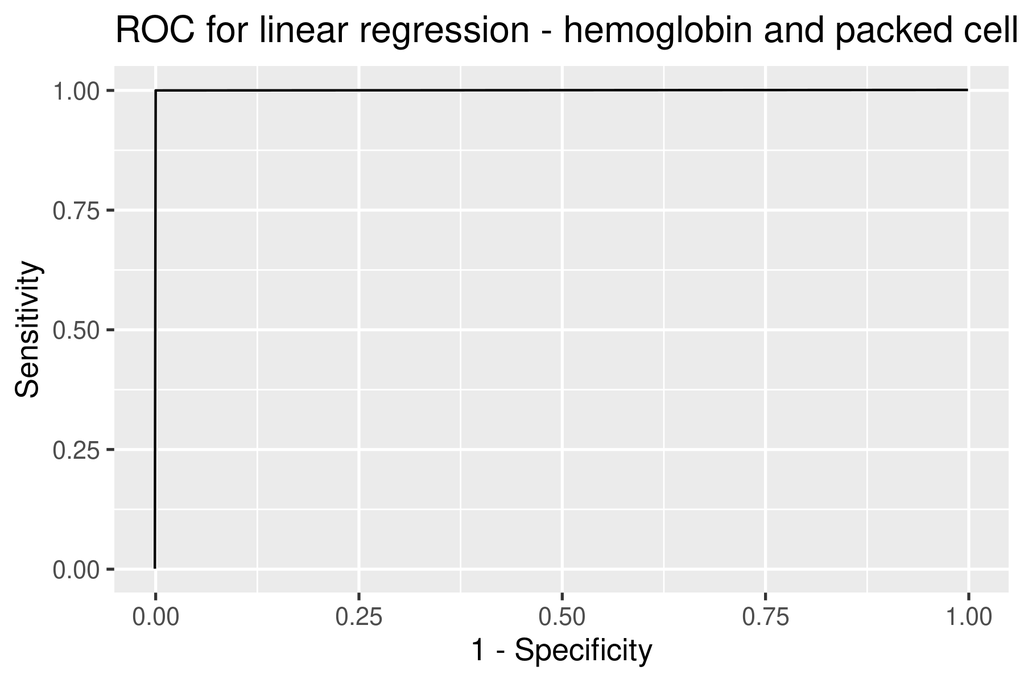

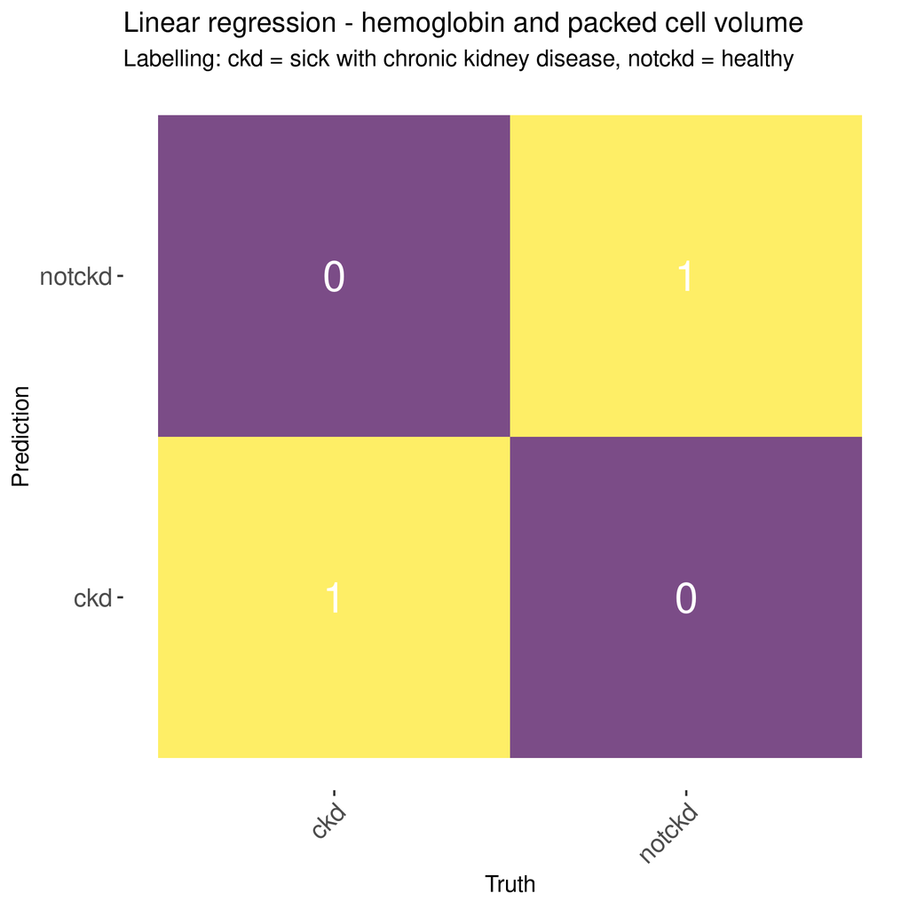

## Modelling

### K-Nearest Neighbors

- 100% sensitivity at 98% specificity

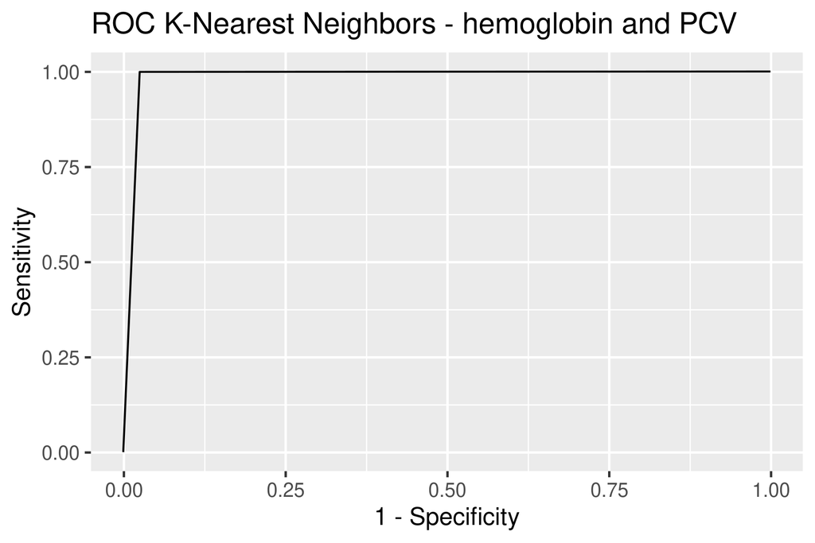

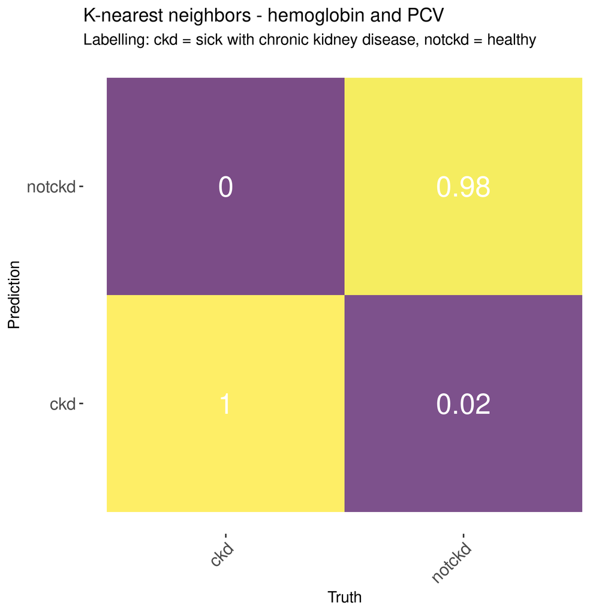

## Modelling

### Model metrics summary

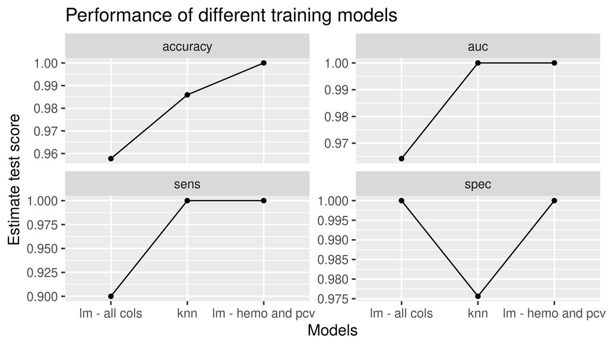

## Modelling

### ROC - All models

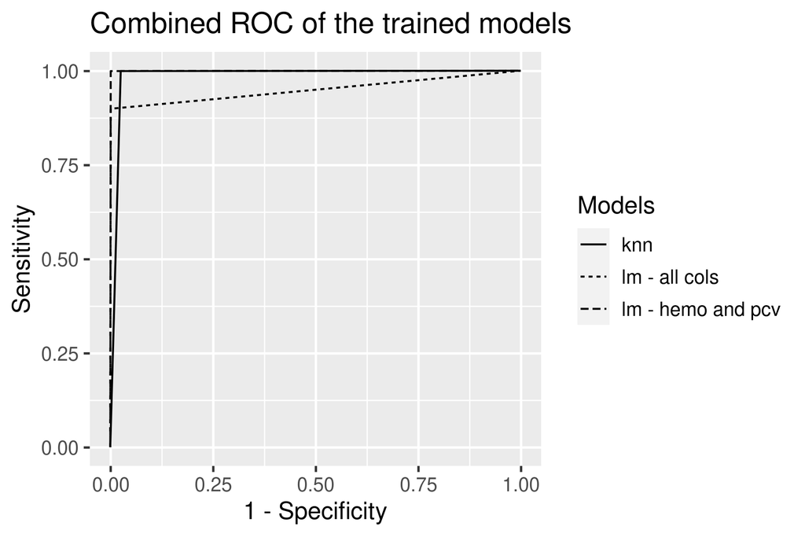

## Conclusion

- Linear regression with hemoglobin and PCV - highest specificity and sensitivity
- Prediction of CKD based only on 2 attributes
- Application in diagnostics
- Future: use of serum creatinine and blood urea in modelling